# 地圖繪製與地理資料建構

Chia-Jung, Yeh

2021-12-16

# **臺灣百岳及人口地圖**

**細節說明：**  
1. `windowsFonts`是用來設定字體的函式。  
2. `scale_＊_distiller`是用來繪製連續型分布的函式，該函式的優勢是可以直接設定調色板（`palette`）。  
3. 利用`arrange(taiwan_peak, Z)`將高程升冪排列，即可使高度較高的山峰疊在高度較低的山峰上，才不會因高低交錯而影響視覺化呈現。  
4. `theme_void`是用來將所有經緯度座標軸和底圖刪除的函式。  
5. 以下程式碼中`scale_color_distiller`用來使點的顏色依高程繪製；`scale_size_continuous`用來使點的大小依高程繪製，預設情況下會產生兩個圖例。若欲將兩圖例合併，可利用`guides(color=guide_legend(), size=guide_legend())`解決。參考文件在[這裡](https://stackoverflow.com/questions/32649426/ggplot-combining-size-and-color-in-legend)。

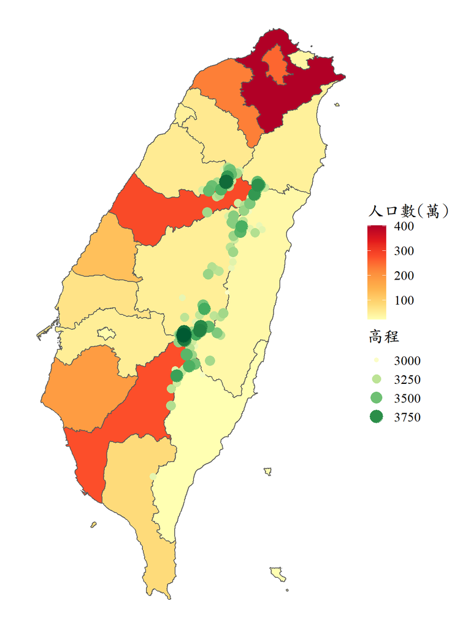

```r
windowsFonts(A=windowsFont("標楷體"))
windowsFonts(B=windowsFont("Times New Roman"))

ggplot()+
  geom_sf(data=tw_county_main, aes(fill=POP/10000))+
  scale_fill_distiller(palette="YlOrRd", direction=1, name="人口數(萬)")+
  geom_sf(data=arrange(taiwan_peak, Z), aes(color=Z,size=Z))+
  scale_color_distiller(palette="YlGn", direction=1, name="高程")+
  scale_size_continuous(range=c(1,6), name="高程")+
  theme_void()+
  theme(legend.title=element_text(size=15, family="A"),
        legend.text=element_text(size=12, family="B"))+
  guides(color=guide_legend(), size=guide_legend())
```

# **文字檔轉換為地理資料**

從網路上下載的文字檔若遇轉換為地理資料，通常原始資料型態會是以下兩種類型：  
1. 資料中含有[WKT格式](https://chiajung-yeh.github.io/Spatial-Analysis/basic-knowledge-on-gis.html#well-known-text-wkt)的空間資料（如`TWspdata`套件中的hsinchu_bus_route）  
2. 資料中含有經緯度資料，分別儲存與兩欄位中（如`TWspdata`套件中的hsinchu_scenicSpot）

將純文字資料轉換為地理資料的方法，程式碼撰寫架構如下：

```r
# 利用st_as_sf()函式將WKT格式轉換為空間資料
DATA$geometry=st_as_sfc(DATA$geometry)

# 再將整個資料轉換為地理資料，並設定參考座標格式
DATA=st_sf(DATA, crs=)
```

以下分別介紹兩種資料類型轉換為地理資料的方式。

## 含有WKT的資料

原始的hsinchu_bus_route資料是文字格式，其中空間資料以WKT格式儲存於Geometry欄位。

```r
# 檢查原始資料型態
class(hsinchu_bus_route)
```

```
## [1] "data.frame"
```

接著利用`st_as_sfc()`函式將Geometry欄位之文字資料，轉換為具空間意義的資料。

```r
# 轉換純文字為空間資料
hsinchu_bus_route$Geometry=st_as_sfc(hsinchu_bus_route$Geometry)
```

此時我們只是將Geometry欄位轉換為空間資料，但整個hsinchu_bus_route資料的格式仍然是`data.frame`。

```r
class(hsinchu_bus_route)
```

```
## [1] "data.frame"
```

因此，最後必須將hsinchu_bus_route轉換為地理資料，並設定CRS。

```r
# 原始資料採用經緯度記錄，故設定為全球通用的座標參考系統（EPSG:4326）
hsinchu_bus_route=st_sf(hsinchu_bus_route, crs=4326)
```

繪圖結果如下：

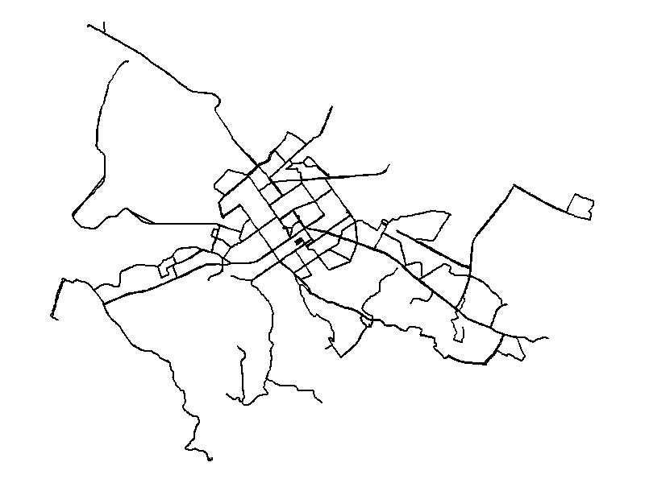

```r
ggplot()+
  geom_sf(data=hsinchu_bus_route)+
  theme_void()
```

## 含有經緯度欄位的資料

原始的hsinchu_scenicSpot資料是文字格式，其中空間資料以經緯度形式儲存於兩欄位（PositionLat、PositionLon）。

```r
# 檢查原始資料型態
class(hsinchu_scenicSpot)
```

```
## [1] "data.frame"
```

```r
# 查看前六筆資料
head(hsinchu_scenicSpot)
```

```
##                     ID               Name PositionLat PositionLon
## 1 C1_376580000A_000101 新竹公園(中山公園)    24.80125    120.9771
## 2 C1_376580000A_000029             進士第    24.80947    120.9653
## 3 C1_376580000A_000037         楊氏節孝坊    24.80311    120.9646
## 4 C1_376580000A_000045         香山火車站    24.76312    120.9139
## 5 C1_376580000A_000085       于飛島(鳥島)    24.77494    120.9718
## 6 C1_376580000A_000079   十草原(櫻花草原)    24.76732    120.9379
```

由於資料中並無geometry欄位，應先自行建立一個WKT格式。  
點資料的WKT格式為「`POINT (X Y)`」。

```r
hsinchu_scenicSpot$geometry=paste0("POINT(", hsinchu_scenicSpot$PositionLon, " ", hsinchu_scenicSpot$PositionLat, ")")
```

接著將新建立的WKT格式轉換為空間資料。

```r
hsinchu_scenicSpot$geometry=st_as_sfc(hsinchu_scenicSpot$geometry)

# 查看結果
head(hsinchu_scenicSpot)
```

```
##                     ID               Name PositionLat PositionLon
## 1 C1_376580000A_000101 新竹公園(中山公園)    24.80125    120.9771
## 2 C1_376580000A_000029             進士第    24.80947    120.9653
## 3 C1_376580000A_000037         楊氏節孝坊    24.80311    120.9646
## 4 C1_376580000A_000045         香山火車站    24.76312    120.9139
## 5 C1_376580000A_000085       于飛島(鳥島)    24.77494    120.9718
## 6 C1_376580000A_000079   十草原(櫻花草原)    24.76732    120.9379
##                    geometry
## 1 POINT (120.9771 24.80125)
## 2 POINT (120.9653 24.80947)
## 3 POINT (120.9646 24.80311)
## 4 POINT (120.9139 24.76312)
## 5 POINT (120.9718 24.77494)
## 6 POINT (120.9379 24.76732)
```

最後必須將hsinchu_scenicSpot轉換為地理資料，並設定CRS。

```r
# 原始資料採用經緯度記錄，故設定為全球通用的座標參考系統（EPSG:4326）
hsinchu_scenicSpot=st_sf(hsinchu_scenicSpot, crs=4326)
```

繪圖結果如下：

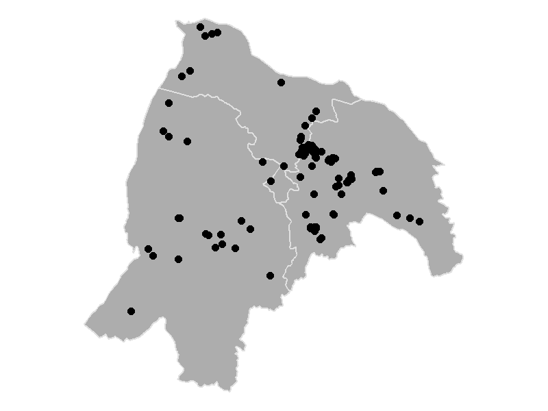

```r
ggplot()+
  geom_sf(data=filter(taiwan_town, COUNTYNAME=="新竹市"), fill="#ADADAD", color="#E0E0E0")+
  geom_sf(data=hsinchu_scenicSpot)+
  theme_void()
```